# Sample Asciidoctor/LaTeX Document Using Jekdoc Tags

Ivan Jacob Agaloos Pesigan  
i.j.a.pesigan@connect.um.edu.mo  
version 0.0.0, 2020-05-01  
Revision remarks

## Author Note

Ivan Jacob Agaloos Pesigan Department of Psychology, University of Macau; John H. Doe Department of Psychology, University of Macau

Correspondence concerning this article should be addressed to Ivan Jacob Agaloos Pesigan, Department of Psychology, Faculty of Social Sciences, Avenida da Universidade, University of Macau, Taipa, Macau SAR, China. Email: i.j.a.pesigan@connect.um.edu.mo

Abstract

> This document demonstrates how to use `Jekdoc tags`. This document covers the following: headers, text styling, Math, R code, citations, tables and others. The following is a boilerplate text with `Jekdoc tags`. Lorem ipsum dolor sit amet Anderson et al. (2004), consectetur adipiscing elit, sed do eiusmod tempor incididunt ut labore et dolore magna aliqua. Ut enim ad minim veniam, quis nostrud exercitation ullamco laboris nisi ut aliquip ex ea commodo consequat Lane (2000); Mane et al. (2000). *This is bold italic text.* Duis aute irure dolor in reprehenderit in voluptate velit esse cillum dolore eu fugiat nulla pariatur. Excepteur sint occaecat cupidatat non proident, sunt in culpa qui officia deserunt mollit anim id est laborum. **This is bold text.** *This is italic text.* “This is text in double quote.” ‘This is text in single quote.’ This is an example of text with<sup>superscript</sup>. This is an example of text with<sub>subscript</sub>. `This is monospace text.` This is an inline Math equation with `R` code \(\pi = 3.1415927\).

*Keywords:* Jekdoc, Asciidoc, Latex

## Header 1

### Header 2

#### Header 3

##### Header 4

###### Header 5

## Text Styling

Lorem ipsum dolor sit amet, consectetur adipiscing elit, sed do eiusmod tempor incididunt ut labore et dolore magna aliqua. Ut enim ad minim veniam, quis nostrud exercitation ullamco laboris nisi ut aliquip ex ea commodo consequat. *This is bold italic text.* Duis aute irure dolor in reprehenderit in voluptate velit esse cillum dolore eu fugiat nulla pariatur. Excepteur sint occaecat cupidatat non proident, sunt in culpa qui officia deserunt mollit anim id est laborum. **This is bold text.** *This is italic text.* “This is text in double quote.” ‘This is text in single quote.’ This is an example of text with<sup>superscript</sup>. This is an example of text with<sub>subscript</sub>. `This is monospace text.`

Accented è

## Math

### Inline equation

This is an inline equation: \(\Sigma = \Sigma \left( \theta \right)\).

### Centered equation

\[\begin{equation} \label{eq} c^2 = a^2 + b^2 \end{equation}\]

## R

### Inline

The following are examples of inline `R` code.

Lorem ipsum dolor sit amet, consectetur adipiscing elit, sed do eiusmod tempor incididunt ut labore et dolore magna aliqua. 5, 4, 6, 7.

Ut enim ad minim veniam, 5.5, quis nostrud exercitation ullamco laboris nisi ut aliquip ex ea commodo consequat.

### R code chunk

The following are examples of `R` chunks.

```r
1+1
```

```
## [1] 2
```

```r
rnorm(5)
```

```
## [1]  1.0163007 -0.4759473 -0.5131868  1.0874288 -0.3101443
```

```r
1:2+1:3 # a warning
```

|  | Warning Warning in 1:2 + 1:3: longer object length is not a multiple of shorter object length |
| --- | --- |

```
## [1] 2 4 4
```

```r
f=function(){message('Aloha, this is a friendly message!')}
f()
```

|  | Message Aloha, this is a friendly message! |
| --- | --- |

```r
1+'a' # mision impossible
```

|  | Error ## Error in 1 + "a": non-numeric argument to binary operator |
| --- | --- |

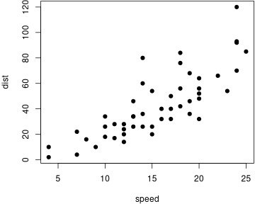

```r
par(mar=c(4, 4, .1, .1))
plot(cars, pch=19)
```

Figure 1. A wonderful plot.

## Citations

Anderson et al. (2004) (citet, single)

Lane (2000); Mane et al. (2000) (citet, multiple)

Anderson, Bothell, Byrne, Douglass, Lebiere, and Qin (2004) (citet*, single)

Lane (2000); Mane and Smith (2000) (citet*, multiple)

Anderson et al. 2004 (citealt, single)

Lane 2000; Mane et al. 2000 (citealt, multiple)

Anderson, Bothell, Byrne, Douglass, Lebiere, and Qin 2004 (citealt*, single)

Lane 2000; Mane and Smith 2000 (citealt*, multiple)

(Anderson et al., 2004) (citep, single)

(Lane, 2000; Mane et al., 2000) (citep, multiple)

(Anderson, Bothell, Byrne, Douglass, Lebiere, and Qin, 2004) (citep*, single)

(Lane, 2000; Mane and Smith, 2000) (citep*, multiple)

Anderson et al., 2004 (citealp, single)

Lane, 2000; Mane et al., 2000 (citealp, multiple)

Anderson, Bothell, Byrne, Douglass, Lebiere, and Qin, 2004 (citealp*, single)

Lane, 2000; Mane and Smith, 2000 (citealp*, multiple)

Anderson et al. (citeauthor, single)

Lane; Mane et al. (citeauthor, multiple)

Anderson, Bothell, Byrne, Douglass, Lebiere, and Qin (citeauthor*, single)

Lane; Mane and Smith (citeauthor*, multiple)

2004 (citeyear, single)

2000; 2000 (citeyear, multiple)

(2004) (citeyearpar, single)

(2000; 2000) (citeyearpar, multiple)

Anderson, J. R., Bothell, D., Byrne, M. D., Douglass, S., Lebiere, C., & Qin, Y. L. (2004). An integrated theory of the mind. *Psychological Review*, *111*(4), 1036–1060. (fullcite)

## Tables

| Heading 1 | Heading 2 | Heading 3 |
| --- | --- | --- |
| 1 | 1 | 1 |
| 2 | 2 | 2 |
| 3 | 3 | 3 |

## Others

No indent text.

## References

Anderson, J. R., Bothell, D., Byrne, M. D., Douglass, S., Lebiere, C., & Qin, Y. L. (2004). An integrated theory of the mind. *Psychological Review*, *111*(4), 1036–1060.

Lane, P. (2000). *Book title*. Publisher.

Mane, K., & Smith, D. (2000). *Book title*. Publisher.

## Appendix

Version 0.0.0  
Last updated 2020-05-01 01:57:45 +0800